# London TfL Accidents Report (2019)

#### Per Capita Accidents Per Borough

To get a better understanding of the significance of the above plot, we should also examine accidents per capita using the borough population data we webscraped seperately from the TfL API. To setup this chart, I performed an inner join between the Borough Population Table and Accidents Table on the “borough” columns.

I then computed accidents per capita for each borough and added that as a column in this new dataframe.

Our resulting plot shows an interesting result that City of Westminster still leads the rest of the boroughs by a considerable amount, even when borough population is taken into account. We will explore more specifically about City of Westminster in the following section.

**Note: Observe same “City of London” note as above**

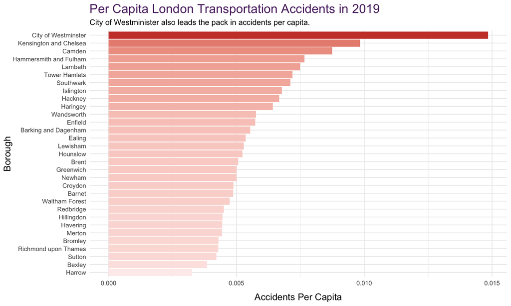

```r
plot_df <- accidents_tbl %>%
    group_by(borough) %>%
    count() %>%
    inner_join(population_tbl) %>%
    mutate("accidents_per_capita" = (as.double(n)/as.double(population))) %>%
    select(borough, accidents_per_capita) %>%

    # Note: removed City of London borough row because its low population & size
    # relative to its high foot traffic skewed this graph considerably.
    filter(borough != "City of London")


  ggplot(plot_df, aes(y=fct_reorder(borough, accidents_per_capita),
                      x=accidents_per_capita)) +

    geom_col(aes(fill = accidents_per_capita)) +

    scale_fill_gradient(low = "#FDEDEC",
                        high = "#CB4335") +

    labs(title = "Per Capita London Transportation Accidents in 2019",
         subtitle = "City of Westminister also leads the pack in accidents per capita.",
         x = "Accidents Per Capita",
         y = "Borough") +

    guides(fill = FALSE) +

    theme_minimal() +
    theme(axis.title = element_text(size = rel(1.2)),
          axis.title.x = element_text(margin = margin(t=10)),
          axis.title.y = element_text(margin = margin(t=0)),
          plot.title = element_text(size=rel(1.6), color="#5B2C6F"))
```

#### Accidents Throughout the Year

To get an overview of the time data, we will examine number of accidents throughout the year. In order to do this, I needed to convert my date column into datetime format, then omit the time information from this column with the lubridate package.

This is a useful illustration that shows how the number of accidents fluctuated throughout 2019. It shows that accidents peak around the end of the year and fall lowest at the beginning of the year.

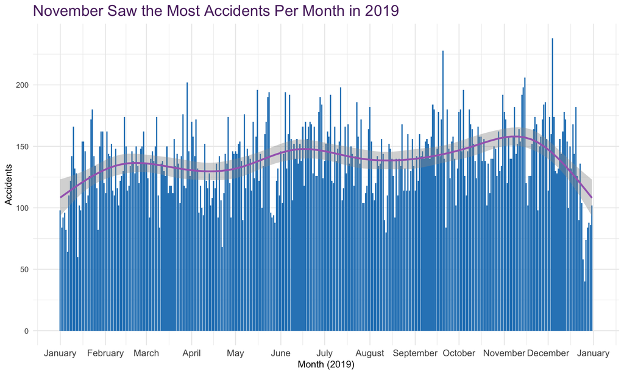

```r
plot_df <- accidents_tbl %>%
    collect() %>%
    mutate(date = as_datetime(date)) %>%
    mutate(date = date(date)) %>%
    group_by(date) %>%
    count()

  ggplot(plot_df, aes(x=date, y=n)) +

    geom_col(fill = "#2E86C1") +

    geom_smooth(method = "gam", level = 0.95, color = "#A569BD") +

    scale_x_date(date_breaks="1 month", date_labels="%B") +

    labs(title = "November Saw the Most Accidents Per Month in 2019",
         x = "Month (2019)",
         y = "Accidents") +

    theme_minimal() +
    theme(axis.text.x = element_text(size = rel(1.2)),
          plot.title = element_text(size=rel(1.6), color="#5B2C6F"))
```

#### Casualties by Mode of Transport

We now want to find out how these injuries are happening, so we will inspect the mode column of the Casualties Table. This graph shows us the mode by which the injured person was traveling. So, “Car” means that the injured person was a driver or passenger in a car, “Pedestrian” means that the injured person was traveling on foot, etc.

We see that drivers or passengers of cars experienced the most amount of casualties over other methods of transportation. It is important to remember that TfL defines “casualties” not as deaths, but as injuries that are either slight, serious, or fatal.

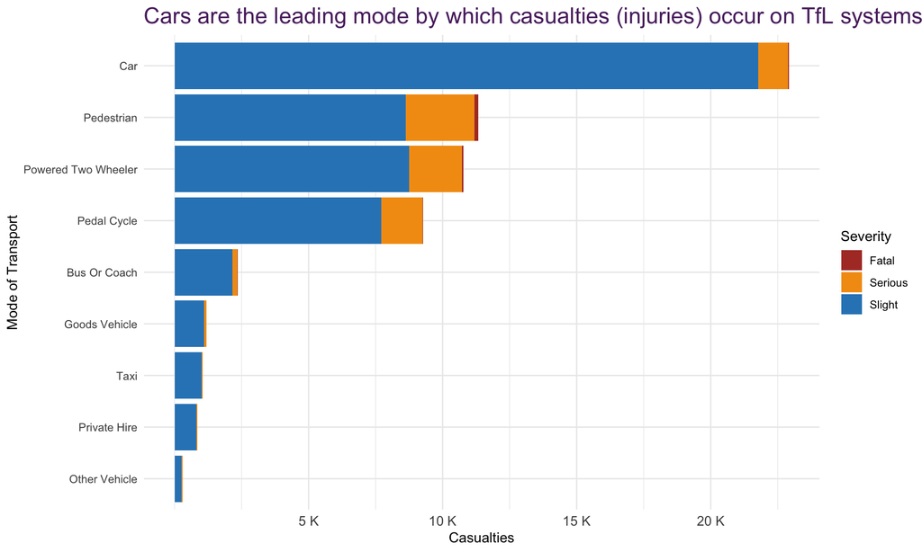

```r
ggplot(casualties_tbl, aes(y=fct_rev(fct_infreq(mode)))) +

    geom_bar(aes(fill=severity)) +

    scale_fill_manual(values = c("Slight" = "#2E86C1",
                                 "Serious" = "#F39C12",
                                 "Fatal" = "#B03A2E"),
                      name = "Severity") +

    scale_x_continuous(breaks = seq(5000, 25000, 5000),
                       labels = scales::unit_format(unit="K", scale = 1e-3)) +

    labs(title = "Cars are the leading mode by which casualties (injuries) occur on TfL systems",
         x = "Casualties",
         y = "Mode of Transport") +

    theme_minimal() +
    theme(axis.text.x = element_text(size = rel(1.2)),
          plot.title = element_text(size=rel(1.6), color="#5B2C6F"))
```

#### Serious or Fatal Casualties by Mode of Transport

When we restrict the Casualties Table to only include serious or fatal casualties, we see an interesting result: Pedestrian, Motorcycle, and Bicycle casualties overtake Car casualties when “slight” casualties are not considered. This may mean that Car injuries are more frequent, yet Pedestrian, motorcycle, and bicycle injuries are more dangerous.

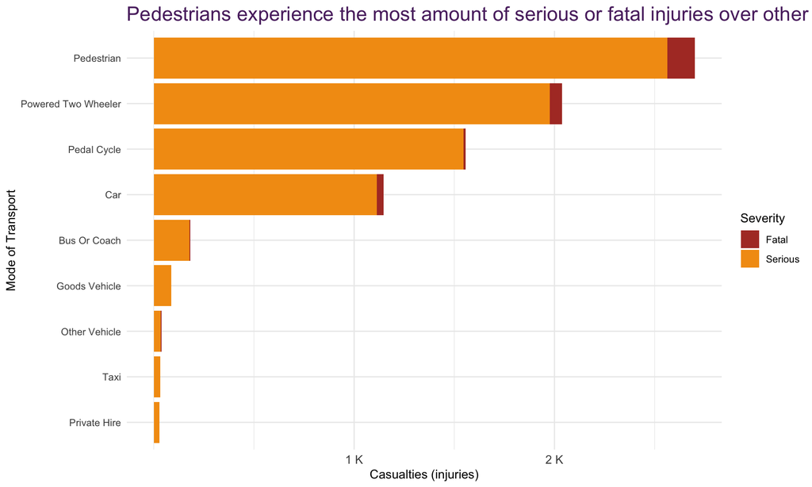

```r
ggplot(casualties_tbl %>%
           filter(severity != "Slight"),
         aes(y=fct_rev(fct_infreq(mode)))) +

    geom_bar(aes(fill=severity)) +

    scale_fill_manual(values = c("Serious" = "#F39C12",
                                 "Fatal" = "#B03A2E"),
                      name = "Severity") +

    scale_x_continuous(breaks = seq(1000, 3000, 1000),
                       labels = scales::unit_format(unit="K", scale = 1e-3)) +

    labs(title = "Pedestrians experience the most amount of serious or fatal injuries over other modes of transport",
         x = "Casualties (injuries)",
         y = "Mode of Transport") +

    theme_minimal() +
    theme(axis.text.x = element_text(size = rel(1.2)),
          plot.title = element_text(size=rel(1.6), color="#5B2C6F"))
```

# 📈 Further Exploratory Analysis

#### Accidents Per Hour

We want to find out what times of day led to the most accidents in 2019. To create this ciruclar barplot, I needed to apply the `coord_polar()` function to the barplot of my preprocessed dataframe.

Using lubridate, I converted my date column to datetime format, then pulled only the hour element from my date data into a new hour column. Then, grouping by hour, I was albe to visualize the problematic hours. The morning and evening spikes can likely be attributed to rush hour transport, which is what we expect.

It is interesting that the 8am spike is much more abrupt than the gradual 3-6pm spike. This shows how it gradually gets busier in the evenings, followed by a sharp drop off after 7pm.

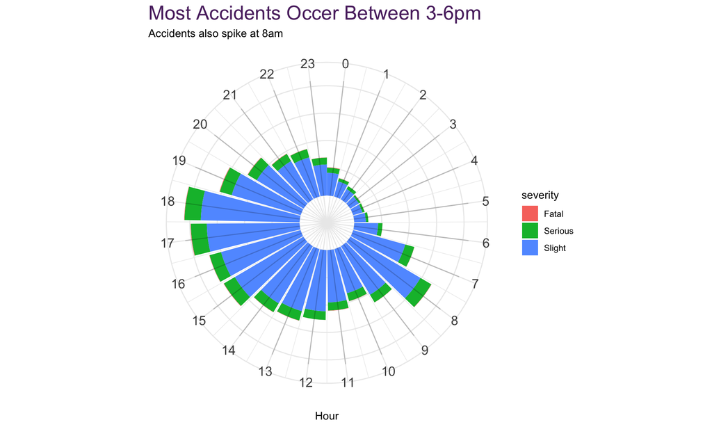

```r
plot_df <- accidents_tbl %>%
    collect() %>%
    mutate(date = as_datetime(date)) %>%
    mutate(hour = hour(date)) %>%
    group_by(hour)


  ggplot(plot_df, aes(x=hour)) +

    geom_bar(aes(fill = severity)) +

    annotate('segment',
             x= seq(0, 23),
             y = 0,
             xend = seq(0, 23),
             yend = 4204,

             alpha = 0.2) +

    scale_y_continuous(
      limits = c(-1000, 4204),
      expand = c(0, 0)) +

    scale_x_continuous(breaks = seq(0, 23)) +

    labs(title = "Most Accidents Occer Between 3-6pm",
         subtitle = "Accidents also spike at 8am",
         x = "Hour",
         y = "") +

    theme_minimal() +
    theme(plot.title = element_text(size = rel(1.8),
                                    color="#5B2C6F"),
          axis.text.x = element_text(size = rel(1.5)),
          axis.text.y = element_blank()) +

    coord_polar()
```

They are all followed by different preprocessing procedures that extract the specific information we want for each given graph.

Also, each of the following plots contained a mutate call including the `cut()` function to sort the ages in the data into 10-year bins so that the visualization was more informative.

#### Age Range for All Boroughs

We see that 21-30 year olds experience the highest number of transport accidents across all boroughs.

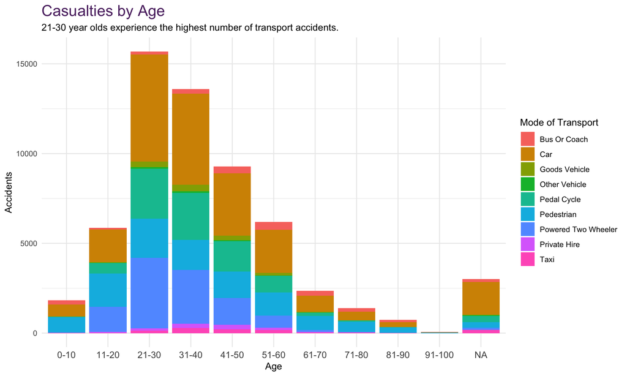

```r
plot_df <- accidents_tbl %>%

    inner_join(casualties_tbl,
               by = c("id" = "accidentId")) %>%

    select(borough,
           age,
           "severity" = severity.x,
           mode) %>%

    mutate(age_range = as.character(cut(age,
                                        breaks = c(0, 10, 20, 30, 40, 50,
                                                   60, 70, 80, 90, 100),
                                        labels = c("0-10", "11-20",
                                                   "21-30", "31-40",
                                                   "41-50", "51-60",
                                                   "61-70", "71-80",
                                                   "81-90", "91-100"))))


  ggplot(plot_df) +

    geom_bar(aes(x = age_range,
                 fill = mode)) +

    guides(fill = guide_legend(title = "Mode of Transport")) +

    labs(title = "Casualties by Age",
         subtitle = "21-30 year olds experience the highest number of transport accidents.",
         x = "Age",
         y = "Accidents") +

    theme_minimal() +
    theme(axis.text.x = element_text(size = rel(1.2)),
          plot.title = element_text(size=rel(1.6), color="#5B2C6F"))
```

#### Age Range for Borough of Harrow

I wanted to take a look at the Borough of Harrow since it had the lowest accidents per capita in all of London. We see that the accidents are much more evenly spread out among different age groups.

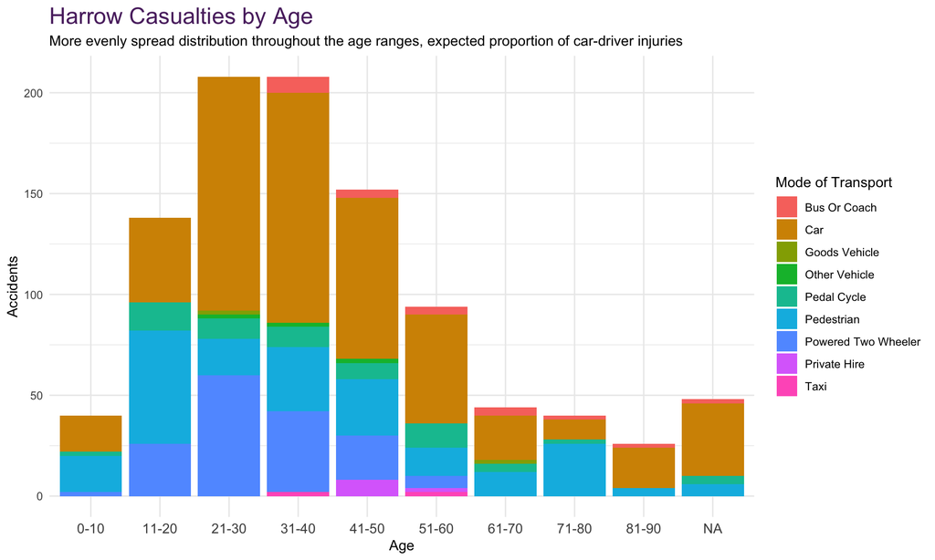

```r
plot_df <- accidents_tbl %>%
    inner_join(casualties_tbl, by = c("id" = "accidentId")) %>%
    select(borough, age, "severity" = severity.x, mode) %>%
    filter(borough == "Harrow") %>%
    mutate(age_range = as.character(cut(age,
                                        breaks = c(0, 10, 20, 30, 40, 50,
                                                   60, 70, 80, 90, 100),
                                        labels = c("0-10", "11-20",
                                                   "21-30", "31-40",
                                                   "41-50", "51-60",
                                                   "61-70", "71-80",
                                                   "81-90", "91-100"))))


  ggplot(plot_df) +

    geom_bar(aes(x = age_range,
                 fill = mode)) +

    guides(fill = guide_legend(title = "Mode of Transport")) +

    labs(title = "Harrow Casualties by Age",
         subtitle = "More evenly spread distribution throughout the age ranges, expected proportion of car-driver injuries",
         x = "Age",
         y = "Accidents") +

    theme_minimal() +
    theme(axis.text.x = element_text(size = rel(1.2)),
          plot.title = element_text(size=rel(1.6), color="#5B2C6F"))
```

#### Age range for City of Westminster

###### Severe or Fatal Cases

This chart continues to illustrate how relatively insignificant Car injuries are when only focusing on Severe or Fatal injuries. We see the majority of each age group occupied by Pedestrian or Bicycle injuries and much less diversity overall in modes of transport.

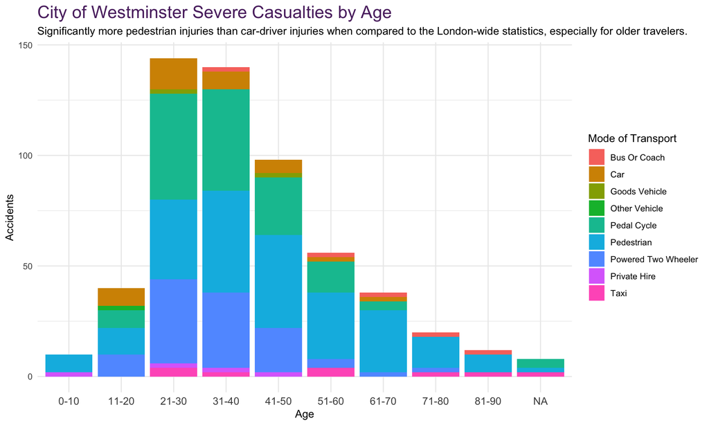

```r
plot_df <- accidents_tbl %>%
    inner_join(casualties_tbl, by = c("id" = "accidentId")) %>%
    select(borough, age, "severity" = severity.x, mode) %>%
    filter(borough == "City of Westminster",
           severity != "Slight") %>%
    mutate(age_range = as.character(cut(age,
                                        breaks = c(0, 10, 20, 30, 40, 50,
                                                   60, 70, 80, 90, 100),
                                        labels = c("0-10", "11-20",
                                                   "21-30", "31-40",
                                                   "41-50", "51-60",
                                                   "61-70", "71-80",
                                                   "81-90", "91-100"))))

  ggplot(plot_df) +

    geom_bar(aes(x = age_range,
                 fill = mode)) +

    guides(fill = guide_legend(title = "Mode of Transport")) +

    labs(title = "City of Westminster Severe Casualties by Age",
         subtitle = "Significantly more pedestrian injuries than car-driver injuries when compared to the London-wide statistics, especially for older travelers.",
         x = "Age",
         y = "Accidents") +

    theme_minimal() +
    theme(axis.text.x = element_text(size = rel(1.2)),
          plot.title = element_text(size=rel(1.6), color="#5B2C6F"))
```